# Statistics

Bakro

12/27/2021

## Probability

| Function | Purpose |
| --- | --- |
| dnorm | Normal density |
| pnorm | Normal distribution function |
| qnorm | Normal quantile function |
| rnorm | Normal random variates |

## distributions types

### Discrete distribution R

| name | rname | params |
| --- | --- | --- |
| Binomial | binom | n = number of trials; p = probability of success for one trial |
| Geometric | geom | p = probability of success for one trial |
| Hypergeometric | hyper | m = number of white balls in urn; n = number of black balls in urn; k = numberof balls drawn from urn |
| Negative binomial (NegBinomial) | nbinom | size = number of successful trials; either prob = probability of successful trial or mu = mean |
| Poisson | pois | lambda = mean |

### continuous distribution

[output not shown]

```r
?Normal
```

```
## starting httpd help server ... done
```

```r
?TDist
```

**Counting the Number of Combinations**

n!/r!(n − r)!

```r
choose(5,3) # How many ways can we select 3 items from 5 items?
```

```
## [1] 10
```

```r
# These numbers are also known as binomial coefficients.
```

**Generating Combinations**

```r
combn(1:5,3)
```

```
##      [,1] [,2] [,3] [,4] [,5] [,6] [,7] [,8] [,9] [,10]
## [1,]    1    1    1    1    1    1    2    2    2     3
## [2,]    2    2    2    3    3    4    3    3    4     4
## [3,]    3    4    5    4    5    5    4    5    5     5
```

```r
combn(c("T1","T2","T3","T4","T5"), 3)
```

```
##      [,1] [,2] [,3] [,4] [,5] [,6] [,7] [,8] [,9] [,10]
## [1,] "T1" "T1" "T1" "T1" "T1" "T1" "T2" "T2" "T2" "T3"
## [2,] "T2" "T2" "T2" "T3" "T3" "T4" "T3" "T3" "T4" "T4"
## [3,] "T3" "T4" "T5" "T4" "T5" "T5" "T4" "T5" "T5" "T5"
```

**Generating Random Numbers**

```r
runif(1)
```

```
## [1] 0.3103827
```

```r
rnorm(1)
```

```
## [1] 1.485468
```

```r
runif(10)
```

```
##  [1] 0.21915673 0.72610559 0.64651036 0.05361674 0.34301985 0.66400690
##  [7] 0.56881319 0.60202466 0.60232668 0.28337242
```

```r
runif(1, min=-3, max=3) # One uniform variate between -3 and +3
```

```
## [1] -0.4371936
```

```r
rnorm(1) # One standard Normal variate
```

```
## [1] 1.048845
```

```r
rnorm(10, mean=100, sd=15) # One Normal variate, mean 100 and SD 15
```

```
##  [1] 109.02148 108.03434 119.18064  71.29056  83.88402  93.14634 141.79418
##  [8] 111.71963 129.08733 124.96964
```

```r
rbinom(10, size=10, prob=0.5) # One binomial variate
```

```
##  [1] 6 6 4 4 6 4 6 3 5 5
```

```r
rpois(10, lambda=10) # One Poisson variate
```

```
##  [1] 13 10 10  9  9  3 12 11 16 11
```

```r
rexp(10, rate=0.1) # One exponential variate
```

```
##  [1]  5.385671 42.126859 37.010528  5.622674  2.216945  4.911299  2.480832
##  [8]  1.898417  7.515205 18.318510
```

```r
rgamma(10, shape=2, rate=0.1) # One gamma variate
```

```
##  [1] 28.954367 17.248763  7.965924  5.249017 24.070623 11.290000  3.883006
##  [8] 13.598898 21.552483 24.856444
```

```r
rnorm(3, mean=c(-10,0,+10), sd=1)
```

```
## [1] -9.8757206 -0.5918608  9.3262857
```

```r
means <- rnorm(100, mean=0, sd=0.2)
```

**Generating Reproducible Random Numbers**

```r
set.seed(666)
runif(10)
```

```
##  [1] 0.77436849 0.19722419 0.97801384 0.20132735 0.36124443 0.74261194
##  [7] 0.97872844 0.49811371 0.01331584 0.25994613
```

**Generating a Random Sample**

```r
n = seq(1990 , 2015 )
sample(n, 10)
```

```
##  [1] 1990 2007 1992 1994 2002 2004 2013 2014 2006 2005
```

**Generating Random Sequences**

sample(set, n, replace=TRUE)

```r
sample(c("H","T"), 10, replace=TRUE)
```

```
##  [1] "T" "H" "T" "H" "T" "T" "H" "H" "T" "T"
```

```r
sample(c(FALSE,TRUE), 20, replace=TRUE)
```

```
##  [1]  TRUE FALSE  TRUE  TRUE FALSE  TRUE  TRUE  TRUE  TRUE  TRUE  TRUE  TRUE
## [13]  TRUE  TRUE  TRUE FALSE  TRUE FALSE FALSE  TRUE
```

```r
sample(c(FALSE,TRUE), 20, replace=TRUE, prob=c(0.2,0.8))
```

```
##  [1]  TRUE  TRUE FALSE  TRUE  TRUE  TRUE FALSE  TRUE  TRUE FALSE  TRUE  TRUE
## [13] FALSE  TRUE FALSE  TRUE  TRUE  TRUE FALSE  TRUE
```

```r
rbinom(10, 1, 0.8)
```

```
##  [1] 1 1 1 0 0 1 1 1 0 1
```

**Randomly Permuting a Vector**

sample(v, size=length(v), replace=FALSE)

```r
sample(1:10)
```

```
##  [1]  7 10  2  8  4  3  6  1  9  5
```

**Calculating Probabilities for Discrete Distributions**

**Problem**

You want to calculate either the simple or the cumulative probability associated with

a discrete random variable.

**Solution**

For a simple probability, P(X = x), use the density function. All built-in probability

distributions have a density function whose name is “d” prefixed to the distribution

name—for example, dbinom for the binomial distribution.

For a cumulative probability, P(X ≤ x), use the distribution function. All built-in probability

distributions have a distribution function whose name is “p” prefixed to the

distribution name; thus, pbinom is the distribution function for the binomial

distribution.

```r
# Suppose we have a binomial random variable X over 10 trials, where each trial has
#  a success probability of 1/2. Then we can calculate the probability of observing x = 7 by calling dbinom:

dbinom(7, size=10, prob=0.5)
```

```
## [1] 0.1171875
```

```r
# The cumulative probability, P(X ≤ x), is given by the distribution function,
# which is sometimes called the cumulative probability function. The distribution function for the binomial distribution is pbinom. Here is the cumulative probability for x = 7 (i.e., P(X ≤ 7)):
pbinom(7, size=10, prob=0.5)
```

```
## [1] 0.9453125
```

```r
# It appears the probability of observing X ≤ 7 is about 0.945.
```

```r
pbinom(7, size=10, prob=0.5, lower.tail=FALSE)
```

```
## [1] 0.0546875
```

```r
#The interval probability, P(x1 < X ≤ x2), is the probability of observing X between the limits x1 and x2. It is simply calculated as the difference between two cumulative probabilities:
# P(X ≤ x2) − P(X ≤ x1). Here is P(3 < X ≤ 7) for our binomial variable:
pbinom(7,size=10,prob=0.5) - pbinom(3,size=10,prob=0.5)
```

```
## [1] 0.7734375
```

```r
pbinom(c(3,7), size=10, prob=0.5)
```

```
## [1] 0.1718750 0.9453125
```

```r
diff(pbinom(c(3,7), size=10, prob=0.5))
```

```
## [1] 0.7734375
```

**Calculating Probabilities for Continuous Distributions**

**Problem**

You want to calculate the distribution function (DF) or cumulative distribution function

(CDF) for a continuous random variable.

**Solution**

Use the distribution function, which calculates P(X ≤ x). All built-in probability distributions

have a distribution function whose name is “p” prefixed to the distribution’s

abbreviated name—for instance, pnorm for the Normal distribution.

**Discussion**

The R functions for probability distributions follow a consistent pattern, so the solution

to this recipe is essentially identical to the solution for discrete random variables

(Recipe 8.8). The significant difference is that continuous variables have no “probability”

at a single point, P(X = x). Instead, they have a density at a point.

Given that consistency, the discussion of distribution functions in Recipe 8.8 is

applicable here, too. The following table gives the distribution function for several

continuous distributions:

| Distribution | Distribution function: P(X ≤ x) |
| --- | --- |
| Normal | pnorm(x, mean, sd) |
| Student’s t | pt(x, df) |
| Exponential | pexp(x, rate) |
| Gamma | pgamma(x, shape, rate) |
| Chi-squared (χ2) | pchisq(x, df) |

```r
# X ~ N(70, 3):
 pnorm(66, mean=70, sd=3)
```

```
## [1] 0.09121122
```

```r
# Likewise, we can use pexp to calculate the probability that an exponential variable with a mean of 40 could be less than 20:
pexp(20, rate=1/40)
```

```
## [1] 0.3934693
```

```r
# Just as for discrete probabilities, the functions for continuous probabilities
# use lower.tail=FALSE to specify the survival function, P(X > x). This call to pexp gives the probability that the same exponential variable could be greater than 50:
pexp(50, rate=1/40, lower.tail=FALSE)
```

```
## [1] 0.2865048
```

```r
# Also like discrete probabilities, the interval probability for a continuous variable, P(x1 <X < x2), is computed as the difference between two cumulative probabilities, P(X < x2) − P(X < x1). For the same exponential variable, here is P(20 < X < 50), the probability that it could fall between 20 and 50:

 pexp(50,rate=1/40) - pexp(20,rate=1/40)
```

```
## [1] 0.3200259
```

**Converting Probabilities to Quantiles**

**Problem**

Given a probability p and a distribution, you want to determine the corresponding

quantile for p: the value x such that P(X ≤ x) = p.

**Solution**

Every built-in distribution includes a quantile function that converts probabilities to

quantiles. The function’s name is “q” prefixed to the distribution name; thus, for instance,

qnorm is the quantile function for the Normal distribution.

The first argument of the quantile function is the probability. The remaining arguments

are the distribution’s parameters, such as mean, shape, or rate:

```r
qnorm(0.05, mean=100, sd=15)
```

```
## [1] 75.3272
```

| Distribution | Quantile function |
| --- | --- |
| Binomial | qbinom(p, size, prob) |
| Geometric | qgeom(p, prob) |
| Poisson | qpois(p, lambda) |
| Normal | qnorm(p, mean, sd) |
| Student’s t | qt(p, df) |
| Exponential | qexp(p, rate) |
| Gamma | qgamma(p, shape, rate=rate) or qgamma(p, shape, scale=scale) |
| Chi-squared (χ2) | qchisq(p, df) |

**Plotting a Density Function**

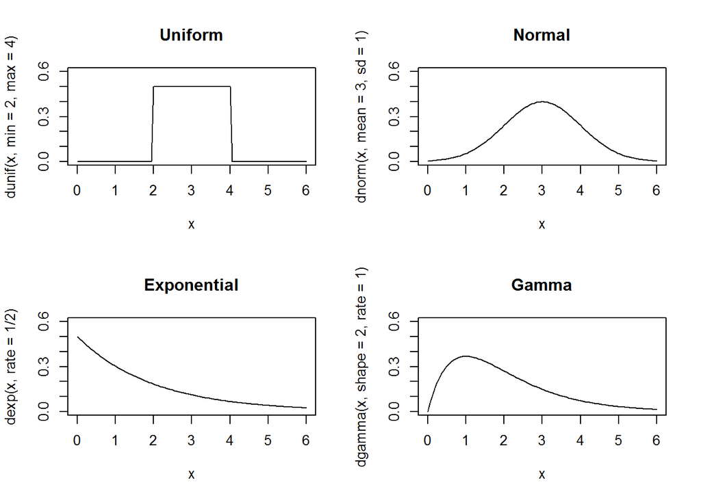

```r
x <- seq(from=0, to=6, length.out=100) # Define the density domains
ylim <- c(0, 0.6)
par(mfrow=c(2,2)) # Create a 2x2 plotting area
plot(x, dunif(x,min=2,max=4), main="Uniform", # Plot a uniform density
type='l', ylim=ylim)
plot(x, dnorm(x,mean=3,sd=1), main="Normal", # Plot a Normal density
type='l', ylim=ylim)
plot(x, dexp(x,rate=1/2), main="Exponential", # Plot an exponential density
type='l', ylim=ylim)
plot(x, dgamma(x,shape=2,rate=1), main="Gamma", # Plot a gamma density
type='l', ylim=ylim)
```

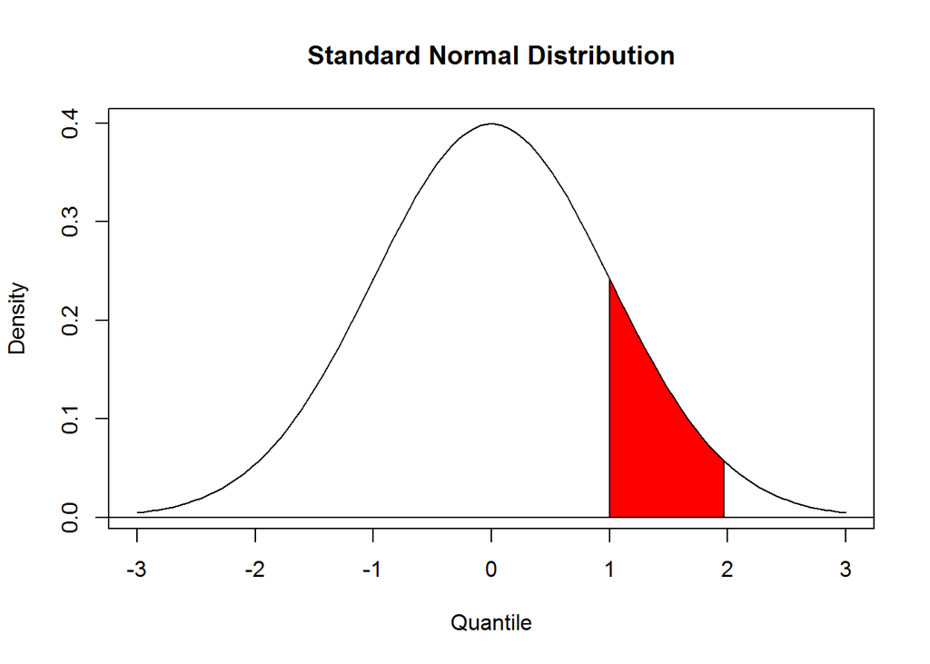

```r
x <- seq(from=-3, to=+3, length.out=100)
y <- dnorm(x)
plot(x, y, main="Standard Normal Distribution", type='l',
ylab="Density", xlab="Quantile")
abline(h=0)

# The body of the polygon follows the density curve where 1 <= z <= 2
region.x <- x[1 <= x & x <= 2]
region.y <- y[1 <= x & x <= 2]
# We add initial and final segments, which drop down to the Y axis
region.x <- c(region.x[1], region.x, tail(region.x,1))
region.y <- c( 0, region.y, 0)

polygon(region.x, region.y, density=-1, col="red")
```